# Animal Crossing Final

Kevin Candray

4/29/2021

# Introduction

For my final independent project for BIOL 551/L : Computer Modeling, I decided to use Tidy Tuesday Animal Crossing New Horizons data. With this data I will be doing a text analysis among the user and critic reviews, astrology chart for villagers birthdays, and do data analysis on how to become a **bell**ionaire.

## Loading in the libraries

```r
library(tidyverse)
library(here)
library(lubridate)
library(tidytext)
library(flair)
library(wordcloud2)
library(DescTools)
```

## Reading and saving all the data

```r
critic <- readr::read_tsv('https://raw.githubusercontent.com/rfordatascience/tidytuesday/master/data/2020/2020-05-05/critic.tsv')
#write.csv(critic, 'criticdfACNH.csv')

user_reviews <- readr::read_tsv('https://raw.githubusercontent.com/rfordatascience/tidytuesday/master/data/2020/2020-05-05/user_reviews.tsv')
#write.csv(user_reviews,'userreviewsACNH.csv')

#villagers <- readr::read_csv('https://raw.githubusercontent.com/rfordatascience/tidytuesday/master/data/2020/2020-05-05/villagers.csv')
#write.csv(villagers, 'villagersACNH.csv')

#items <- readr::read_csv('https://raw.githubusercontent.com/rfordatascience/tidytuesday/master/data/2020/2020-05-05/items.csv')
#write.csv(items, 'itemsACNH.csv')
```

## Setting up color vectors for entire code

```r
isabelle.colors = c("#f1b60b","#fbe98b", "#eef4d2")
isabelle.background = c("#456d38")

nook.colors = c("#8a5123", "#e1803f", "#4d2517")
nook.background = c("#65ccb7")
```

# Text Analysis: What words are commonly used in User and Critic Reviews for Animal Crossing: New Horizons?

## Common User Words:

When running this chunk, it yields a tibble table where the words are descending based on the average grade (1-10) from the *user reviews*. For some odd reason the word **“bombing”** was associated with high average reviews. I looked further into why because there are no **bombs** in the game so why are people saying it in the reviews?

```r
#wrangle data for a word cloud
user_review_words<- user_reviews %>% # calling in data set and creating a new one for the wrangling i will be doing
  unnest_tokens(word, text) %>% #splitting text column into tokens aka words
  anti_join(stop_words, by = "word") %>% #not counting stop words from the english words
  count(user_name, date, grade, word) # count (n) based on usernames words

user_review_words %>% # call in data set
  group_by(word) %>% # group by word
  summarize(avg_grade = mean(grade), #summarize based on average grade and the amount of reviews each word is in
            nb_reviews = n()) %>%
  filter(nb_reviews >=50) %>% #filter the number of reviews to >= 50
  arrange(desc(avg_grade)) #arrange in descending order based on avg_grade
```

```
## # A tibble: 296 x 3
##    word        avg_grade nb_reviews
##    <chr>           <dbl>      <int>
##  1 bombing          8.64         80
##  2 fantastic        8.46         84
##  3 charming         8.29         52
##  4 complaining      8.09         56
##  5 series           7.83        223
##  6 amazing          7.58        212
##  7 perfect          7.56        134
##  8 juego            7.54         85
##  9 es               7.49         65
## 10 relaxing         7.47        168
## # ... with 286 more rows
```

### There was a **bombing**?

Yes you heard it here folks, there was indeed a review bombing during the first few weeks of the games release. With this chunk I will pipe the dataset to show me the reviews that contain the word **“bombing”**

```r
bombing_reviews<- user_reviews %>% #calling in orginal data and saving a new one for just the bombing reviews
  filter(str_detect(text,"bombing")) #detect anywhere in the data set where it mentions "bombing"

head(bombing_reviews$text) #view the top part of the bombing reviews text
```

```
## [1] "Best Animal Crossing game hands down, graphics are gorgeous and gameplay is addicting as always (the moment I was able to pick objects up, I spent an hour picking up weeds XD) So many trolls talking about a horrible co-op experience, more than likely mislead because they don't research a gam…
## [2] "I haven't played animal crossing since Wild World on DS. This game is HD and a great step up. I've enjoyed every aspect of the game. This game is the best animal crossing game to date. People who are review bombing because they can't have seperate islands per switch are just being childish. …
## [3] "Pretty fun game. Relaxing, adorable, and simple. I dont see why people are coming in a review bombing it with 0's metacritic should do somthing about this because its really becoming a problem."
## [4] "Ignore the review bombing haters. This is the best in the series. Sad that people have nothing better to do."
## [5] "This is a very fun game if you are playing single player. Multi-player definitely has its flaws and only being able to have one island per console kind of sucks. Personally I don't find it that much of a problem myself since I'm the only one playing the game and I don't have access to intern…
## [6] "I know about the rating bombing of Animal Crossing and yes the online issue is that...an issue.But this is a guilty pleasure.  So there isn't a MAIN directive of the game but none of them are really.  It's a an awesome game if you overlook the internet flaw."
```

- User *E_Z_E* states, “Ignore the review **bombing** haters.”
- User *Sorites* states, “People who review **bombing** because they can’t have separate islands per switch are just being childish.”
- User *Earthquakemass* states, “I dont see why people are coming in a review **bombing** it with 0’s metacritic should do something about this because its really becoming a problem.”

*TO BE CONTINUED IN DATA ANALYSIS :)…………………………….*

### Making a Wordcloud: wHaT dId ThE uSeRs SaY?

```r
userwords<-user_review_words %>% #making the data set for the wordcloud
  count(word) %>% #count the number of words
  arrange(desc(n)) %>% #arrange the words from descending order based on (n)
  filter(n <=720) %>% #added filter for only showing less than 730 reviews
  slice(1:100)

wordcloud2(userwords, shape = 'star', size = 0.25, minSize = 5, rotateRatio = 0, color = rep_len(isabelle.colors, nrow(userwords)),  backgroundColor = isabelle.background, shuffle = FALSE) #creating word cloud with customizations
```

[interactive chart not shown]

## Common Critic Words:

Similar to the User Reviews for **ACNH**, Critic reviews also had a couple of words that came up consistently such as the title of the game, and the word “game”. I filtered the word *critic_review_words* data so that the number of reviews must be less than or equal to 25.

```r
#wrangle critic data
critic_review_words<- critic %>%#calling in critic data and naming it to something specific for wrangling
  unnest_tokens(word, text) %>% #unnest words from text column and create seperate column for each word
  anti_join(stop_words, by = "word") %>% #do not add stop words to the word column
  count(publication, date, grade, word) #count based on publications each with their words
######## separate pipe so that it is possible to view when knit ###########
critic_review_words %>% #calling in dataframe just wrangled
  group_by(word) %>% #group by word
  summarize(avg_grade = mean(grade), #summarize function for average grade and the number of reviews by n
            nb_reviews = n()) %>%
  filter(nb_reviews <=25) %>% #filter so that the number of reveiws is less than 25
  arrange(desc(nb_reviews)) #arrange table by descending nb_reviews
```

```
## # A tibble: 1,055 x 3
##    word       avg_grade nb_reviews
##    <chr>          <dbl>      <int>
##  1 nintendo        92.1         21
##  2 time            92.1         21
##  3 experience      91.5         17
##  4 life            93.6         17
##  5 switch          91.5         17
##  6 world           94.1         15
##  7 perfect         93.5         13
##  8 franchise       89.6         12
##  9 fun             87.8         12
## 10 games           92.7         12
## # ... with 1,045 more rows
```

On the bright side, there is no “bombing” here so the data analysis won’t look too wonky when we look at the reviews holistically.

### Making a WordCloud: WhAt DiD tHe CrItIcS sAy?

```r
criticloud<- critic_review_words %>% #creating data set for wordcloud
  count(word) %>% #count (n) word
  filter(n <=25) %>% #filter so that n is less than or equal to 25
  arrange(desc(n)) %>% # arrange so that it is in descending order of (n)
  slice(1:100)

wordcloud2(criticloud, shape = 'star', size = .3, minSize = 5, rotateRatio=0, shuffle = FALSE, color = rep_len(nook.colors, nrow(criticloud)), backgroundColor = nook.background) # this doesnt show when knit but does show in output folder and as runned chunk
```

[interactive chart not shown]

After creating both word clouds, I am still having trouble trying to determine what exactly is the difference between the user and critic clouds. The cloluds look relatively similar, both have some matching words such as, “fun, experience, crafting, and time.” So I beg the question . . .

# Sentiment Text Analysis: What is the sentimental value of words for user and critic reviews?

For the sentiment analysis, I will be using the already wrangled data previously used for the word clouds, *user_review_words* and *critic_review_words*, to see if there is any positive or negative connotation to their words in their reviews.

## User Sentiment Analysis

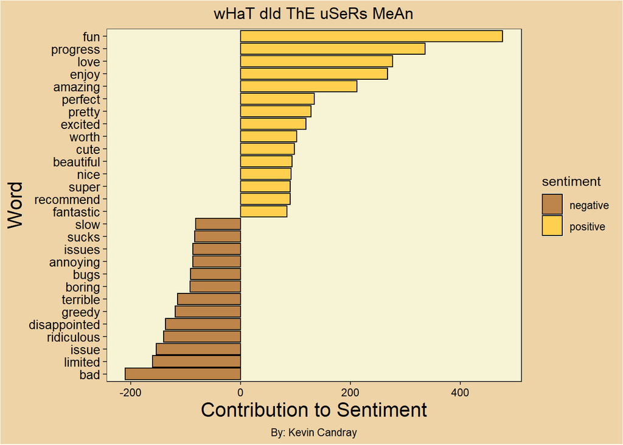

```r
user_sent_word_counts <- user_review_words %>% #calling in user review words and wrangling more for the sentiment analysis, called it someting new
  inner_join(get_sentiments()) %>% #join in new column and get sentiments for each word +/-
  count(word, sentiment, sort = TRUE) #count based on word, sentiment, and then sort the words

user_sent_word_counts %>% #calling in new dataset
  filter(n>80) %>%  #filter the amount of time the word appears, greater than 80
  mutate(n = ifelse(sentiment == "negative",-n,n)) %>% #if the word is negative, make the number negative
  mutate(word = reorder(word, n)) %>% # reorder based on (n)
  #slice(1:100) %>%
  ggplot(aes(word, n, fill = sentiment))+ #creating ggplot
  geom_col(color = "black")+ #columns
  coord_flip()+ #flip the x and y coords
  labs(x = "Word",y = "Contribution to Sentiment",
       title = "wHaT dId ThE uSeRs MeAn", caption = "By: Kevin Candray")+ #labels
  scale_fill_manual(values = c("#bd8549", "#ffcf4f"))+
  theme_bw()+
  theme(axis.text = element_text(size=12),
        axis.title = element_text(size=16),
        axis.text.y = element_text(size = 10, color = "#000000"),
        axis.text.x = element_text(size = 9, color ="#000000" ),
        panel.grid.major = element_blank(),
        plot.caption = element_text(hjust = 0.5),
        plot.title = element_text(hjust = 0.5),
        panel.grid.minor = element_blank(),
        panel.background = element_rect(fill ="#f7f4d5" ),
        plot.background = element_rect(fill = "#eed3a6"),
        legend.background = element_rect(fill = "#eed3a6"))
```

## Critic Sentiment Analysis

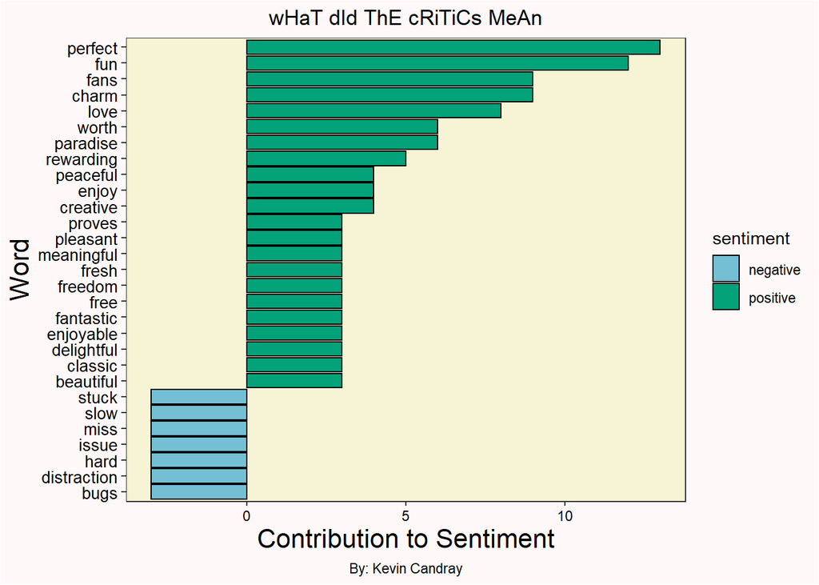

```r
critic_sent_word_counts <- critic_review_words %>%
  inner_join(get_sentiments()) %>%
  count(word, sentiment, sort = TRUE)

critic_sent_word_counts %>%
  filter(n>2) %>%
  mutate(n = ifelse(sentiment == "negative",-n,n)) %>%
  mutate(word = reorder(word, n)) %>%
  ggplot(aes(word, n, fill = sentiment))+
  geom_col(color = "black")+
  coord_flip()+
  labs(x = "Word",y = "Contribution to Sentiment",
       title = "wHaT dId ThE cRiTiCs MeAn", caption = "By: Kevin Candray")+ #labels
  scale_fill_manual(values = c("#74bfd4", "#03a279"))+
  theme_bw()+
  theme(axis.text = element_text(size=12),
        axis.title = element_text(size=16),
        axis.text.y = element_text(size = 10, color = "#000000"),
        axis.text.x = element_text(size = 9, color ="#000000" ),
        panel.grid.major = element_blank(),
        plot.caption = element_text(hjust = 0.5),
        plot.title = element_text(hjust = 0.5),
        panel.grid.minor = element_blank(),
        panel.background = element_rect(fill ="#f7f4d5" ),
        plot.background = element_rect(fill = "#fef9f8"),
        legend.background = element_rect(fill = "#fef9f8"))
```